# Image_Classification_v1.1_final_1

## 'Cars','Ice cream cone','Cricket ball' Classification

We have downloaded the images from google using chrome extension "Fatkun"

Now, Importing all the required packages

```python
import pandas as pd
from sklearn import svm
from sklearn.model_selection import GridSearchCV
import os
import matplotlib.pyplot as plt
from skimage.transform import resize
from skimage.io import imread
import numpy as np
from sklearn.model_selection import train_test_split
from sklearn.metrics import classification_report,accuracy_score,confusion_matrix
import pickle
```

**NOTE** : Please enter Category Names same as folder name

```python
Categories=['Cars','Ice cream cone','Cricket ball']
```

```python
# Checking the categories
Categories
```

```
['Cars', 'Ice cream cone', 'Cricket ball']
```

Plot Cars, Ice Cream Cone & Cricket Ball Photos

```
(0, 'renault-city-k-ze-front-view0.jpeg')
(1, '07car1.jpg')
(2, 'large-2479-s-classsaloon.jpg')
(3, 'xuv300-exterior-rear-view.jpeg')
(4, 'Transpo_G70_TA-518126.jpg')
(5, 'vehicle_1404.jpg')
(6, 'mahindra-tuv300-1.jpg')
(7, 'photo-1552519507-da3b142c6e3d.jfif')
(8, '2018_Toyota_Corolla_(ZRE172R)_Ascent_sedan_(2018-11-02)_01.jpg')
```

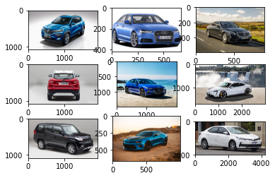

```python
# plot photos from the dataset
from matplotlib import pyplot
from matplotlib.image import imread
# define location of dataset
folder = '/Users/srujanmara/Desktop/UTA Study/Summer 2022/Data Science/Project/complete_dataset/cars/'
# plot first few images
for i in enumerate(os.listdir(folder)[0:9]):
    print(i)
    # define subplot
    pyplot.subplot(330 + 1 + i[0])
    image = imread(folder + i[1])
    # plot raw pixel data
    pyplot.imshow(image)
# show the figure
pyplot.show()
```

```
(0, '1200px-A_Cricket_ball.jpg')
(1, 'WhatsApp_Image_2019-08-17_at_6.29.43_PM_4ef3d4d4-f887-4256-90b5-e052b56969b2_619x.jpeg')
(2, 'FLASH-Mens-Synthetic-Cricket-Ball-Orange.jpeg')
(3, 'cotton-legging-500x500.jpg')
(4, 'dukesinternational.jpg')
(5, 'CDBK15Ball_20Velocity_20Ball_20Red_1500x.jpg')
(6, 'SG_CB_000083_large.jpg')
(7, '4125d5RJ+zL._SX425_.jpg')
(8, '14451_1024x1024.jpg')
```

[figure not shown]

```python
# plot photos from the dataset
from matplotlib import pyplot
from matplotlib.image import imread
# define location of dataset
folder = '/Users/srujanmara/Desktop/UTA Study/Summer 2022/Data Science/Project/complete_dataset/Cricket ball/'
# plot first few images
for i in enumerate(os.listdir(folder)[0:9]):
    print(i)
    # define subplot
    pyplot.subplot(330 + 1 + i[0])
    # load image pixels
    image = imread(folder + i[1])
    # plot raw pixel data
    pyplot.imshow(image)
# show the figure
pyplot.show()
```

```
(0, 'havmor-magic-ice-cream-cones-500x500.jpg')
(1, 'melting-strawberry-ice-cream-cone-kevinruss.jpg')
(2, '220px-Strawberry_ice_cream_cone_(5076899310).jpg')
(3, 'ice-cream-cone-on-pink-background-kevinruss.jpg')
(4, 'chocolate-ice-cream-cone-duckycards.jpg')
(5, 't-mcdonalds-Vanilla-Reduced-Fat-Ice-Cream-Cone.jpg')
(6, 'chocolate-ice-cream-cone-blue-faded-pastel-color-background-chocolate-ice-cream-cone-blue-faded-pastel-color-background-hand-109789561.jpg')
(7, 'black-cone-7.jpg')
(8, 'All-Time-Favourite---Soya-Ice-Cream-Cone-compressor.jpg')
```

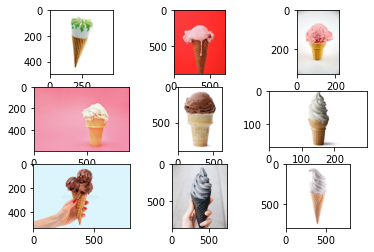

```python
# plot photos from the dataset
from matplotlib import pyplot
from matplotlib.image import imread
# define location of dataset
folder = '/Users/srujanmara/Desktop/UTA Study/Summer 2022/Data Science/Project/complete_dataset/Ice cream cone/'
# plot first few images
for i in enumerate(os.listdir(folder)[0:9]):
    print(i)
    # define subplot
    pyplot.subplot(330 + 1 + i[0])
    # load image pixels
    image = imread(folder + i[1])
    # plot raw pixel data
    pyplot.imshow(image)
# show the figure
pyplot.show()
```

Loading all the images and creating a DataFrame

```python
flat_data_arr=[]
target_arr=[]

datadir='/Users/srujanmara/Desktop/UTA Study/Summer 2022/Data Science/Project/complete_dataset/'
for i in Categories:
    print(f'loading... category : {i}')
    path=os.path.join(datadir,i)
    for img in os.listdir(path):
        img_array=imread(os.path.join(path,img))
        img_resized=resize(img_array,(150,150,3))
        flat_data_arr.append(img_resized.flatten())
        target_arr.append(Categories.index(i))
    print(f'loaded category:{i} successfully')
flat_data=np.array(flat_data_arr)
target=np.array(target_arr)
df=pd.DataFrame(flat_data)
df['Target']=target
df
```

```
loading... category : Cars
loaded category:Cars successfully
loading... category : Ice cream cone
loaded category:Ice cream cone successfully
loading... category : Cricket ball
loaded category:Cricket ball successfully
```

|  | 0 | 1 | 2 | 3 | 4 | 5 | 6 | 7 | 8 | 9 | ... | 67491 | 67492 | 67493 | 67494 | 67495 | 67496 | 67497 | 67498 | 67499 | Target |
| --- | --- | --- | --- | --- | --- | --- | --- | --- | --- | --- | --- | --- | --- | --- | --- | --- | --- | --- | --- | --- | --- |
| 0 | 0.604291 | 0.584683 | 0.600369 | 0.607843 | 0.588235 | 0.603922 | 0.611765 | 0.592157 | 0.607843 | 0.611765 | ... | 0.976471 | 0.976471 | 0.976471 | 0.976471 | 0.976471 | 0.976471 | 0.976471 | 0.976471 | 0.976471 | 0 |
| 1 | 0.996078 | 0.996078 | 0.996078 | 0.996078 | 0.996078 | 0.996078 | 0.996078 | 0.996078 | 0.996078 | 0.996078 | ... | 0.996078 | 0.996078 | 0.996078 | 0.996078 | 0.996078 | 0.996078 | 0.996078 | 0.996078 | 0.996078 | 0 |
| 2 | 0.647059 | 0.705882 | 0.741176 | 0.647059 | 0.706889 | 0.741176 | 0.648013 | 0.708850 | 0.741176 | 0.654902 | ... | 0.443137 | 0.388235 | 0.286275 | 0.448013 | 0.393111 | 0.291150 | 0.450980 | 0.394170 | 0.302967 | 0 |
| 3 | 0.741176 | 0.741176 | 0.733333 | 0.741176 | 0.741176 | 0.733333 | 0.741176 | 0.741176 | 0.733333 | 0.741176 | ... | 0.874510 | 0.874510 | 0.874510 | 0.870588 | 0.870588 | 0.870588 | 0.870588 | 0.870588 | 0.870588 | 0 |
| 4 | 0.488523 | 0.764706 | 0.894118 | 0.491059 | 0.768627 | 0.898039 | 0.494118 | 0.772549 | 0.897516 | 0.498039 | ... | 0.649935 | 0.584314 | 0.482353 | 0.635294 | 0.580392 | 0.483451 | 0.627451 | 0.568627 | 0.474797 | 0 |
| ... | ... | ... | ... | ... | ... | ... | ... | ... | ... | ... | ... | ... | ... | ... | ... | ... | ... | ... | ... | ... | ... |
| 95 | 1.000000 | 1.000000 | 1.000000 | 1.000000 | 1.000000 | 1.000000 | 1.000000 | 1.000000 | 1.000000 | 1.000000 | ... | 1.000000 | 1.000000 | 1.000000 | 1.000000 | 1.000000 | 1.000000 | 1.000000 | 1.000000 | 1.000000 | 2 |
| 96 | 0.607490 | 0.560379 | 0.368641 | 0.644458 | 0.618889 | 0.296065 | 0.655163 | 0.631634 | 0.297923 | 0.631992 | ... | 0.600559 | 0.763963 | 0.320095 | 0.687034 | 0.811062 | 0.518736 | 0.483145 | 0.690222 | 0.026634 | 2 |
| 97 | 0.933333 | 0.937255 | 0.956863 | 0.933333 | 0.937255 | 0.956863 | 0.933333 | 0.937255 | 0.956863 | 0.933333 | ... | 0.933333 | 0.937255 | 0.956863 | 0.933333 | 0.937255 | 0.956863 | 0.933333 | 0.937255 | 0.956863 | 2 |
| 98 | 0.992157 | 0.992157 | 0.992157 | 0.992157 | 0.992157 | 0.992157 | 0.992157 | 0.992157 | 0.992157 | 0.992157 | ... | 0.992157 | 0.992157 | 0.992157 | 0.992157 | 0.992157 | 0.992157 | 0.992157 | 0.992157 | 0.992157 | 2 |
| 99 | 1.000000 | 1.000000 | 1.000000 | 1.000000 | 1.000000 | 1.000000 | 1.000000 | 1.000000 | 1.000000 | 1.000000 | ... | 1.000000 | 1.000000 | 1.000000 | 1.000000 | 1.000000 | 1.000000 | 1.000000 | 1.000000 | 1.000000 | 2 |

100 rows × 67501 columns

Splitting the data into training and testing data

```python
x=df.iloc[:,:-1]
y=df.iloc[:,-1]
x_train,x_test,y_train,y_test=train_test_split(x,y,test_size=0.20,random_state=77,stratify=y)
print('Splitted Successfully')
```

```
Splitted Successfully
```

This Part of code may take a while for training the data using SVC model

Fitting SVM Model

```python
param_grid={'C':[0.1,1,10,100],'gamma':[0.0001,0.001,0.1,1],'kernel':['rbf','poly']}
svc=svm.SVC(probability=True)
print("The training of the model is started, please wait for while as it may take few minutes to complete")
model=GridSearchCV(svc,param_grid)  # using GridSearchCV to find out the optimal parameters
model.fit(x_train,y_train)
print('The Model is trained well with the given images')
model.best_params_
```

```
The training of the model is started, please wait for while as it may take few minutes to complete
The Model is trained well with the given images
```

```
{'C': 10, 'gamma': 0.0001, 'kernel': 'rbf'}
```

```python
svc=svm.SVC(probability=True)
svc.fit(x_train,y_train)
```

```
SVC(probability=True)
```

Predicting our testing data

```python
y_pred=model.predict(x_test)
print("The predicted Data is :")
y_pred
```

```
The predicted Data is :
```

```
array([0, 0, 2, 2, 0, 1, 1, 2, 0, 1, 1, 2, 1, 1, 2, 2, 0, 0, 1, 1])
```

```python
print("The actual data is:")
np.array(y_test)
```

```
The actual data is:
```

```
array([0, 0, 2, 2, 0, 1, 1, 2, 0, 1, 2, 2, 0, 1, 2, 0, 0, 0, 1, 1])
```

# Results for SVM Model

```python
print(classification_report(y_pred,y_test))
print(f"The model is {accuracy_score(y_pred,y_test)*100}% accurate")
confusion_matrix(y_pred,y_test)
```

```
              precision    recall  f1-score   support

           0       0.75      1.00      0.86         6
           1       1.00      0.75      0.86         8
           2       0.83      0.83      0.83         6

    accuracy                           0.85        20
   macro avg       0.86      0.86      0.85        20
weighted avg       0.88      0.85      0.85        20

The model is 85.0% accurate
```

```
array([[6, 0, 0],
       [1, 6, 1],
       [1, 0, 5]])
```

Fitting XGBoost model

```python
from xgboost import XGBClassifier

xgboost = XGBClassifier()
xgboost.fit(x_train,y_train)
```

```
XGBClassifier(base_score=0.5, booster='gbtree', callbacks=None,
              colsample_bylevel=1, colsample_bynode=1, colsample_bytree=1,
              early_stopping_rounds=None, enable_categorical=False,
              eval_metric=None, gamma=0, gpu_id=-1, grow_policy='depthwise',
              importance_type=None, interaction_constraints='',
              learning_rate=0.300000012, max_bin=256, max_cat_to_onehot=4,
              max_delta_step=0, max_depth=6, max_leaves=0, min_child_weight=1,
              missing=nan, monotone_constraints='()', n_estimators=100,
              n_jobs=0, num_parallel_tree=1, objective='multi:softprob',
              predictor='auto', random_state=0, reg_alpha=0, ...)
```

```python
y_pred_xgboost = xgboost.predict(x_test)
print("The predicted Data from the xgboost is :")
y_pred_xgboost
```

```
The predicted Data from the xgboost is :
```

```
array([0, 0, 1, 2, 0, 1, 1, 2, 2, 1, 1, 2, 2, 1, 2, 1, 0, 0, 1, 1])
```

```python
print("The actual data is:")
np.array(y_test)
```

```
The actual data is:
```

```
array([0, 0, 2, 2, 0, 1, 1, 2, 0, 1, 2, 2, 0, 1, 2, 0, 0, 0, 1, 1])
```

Results for XGBoost

```python
print(classification_report(y_pred_xgboost,y_test))
print(f"The model is {accuracy_score(y_pred_xgboost,y_test)*100}% accurate")
confusion_matrix(y_pred_xgboost,y_test)
```

```
              precision    recall  f1-score   support

           0       0.62      1.00      0.77         5
           1       1.00      0.67      0.80         9
           2       0.67      0.67      0.67         6

    accuracy                           0.75        20
   macro avg       0.76      0.78      0.75        20
weighted avg       0.81      0.75      0.75        20

The model is 75.0% accurate
```

```
array([[5, 0, 0],
       [1, 6, 2],
       [2, 0, 4]])
```

Fitting Random Forest Model

```python
from sklearn.ensemble import RandomForestClassifier

randomforest = RandomForestClassifier()
randomforest.fit(x_train,y_train)
```

```
RandomForestClassifier()
```

```python
y_pred_randomforest = randomforest.predict(x_test)
print("The predicted Data from the randomforest is :")
y_pred_randomforest
```

```
The predicted Data from the randomforest is :
```

```
array([0, 0, 1, 2, 0, 1, 1, 2, 0, 1, 1, 2, 2, 1, 2, 1, 0, 0, 1, 1])
```

```python
print("The actual data is:")
np.array(y_test)
```

```
The actual data is:
```

```
array([0, 0, 2, 2, 0, 1, 1, 2, 0, 1, 2, 2, 0, 1, 2, 0, 0, 0, 1, 1])
```

Results for RandomForest

```python
print(classification_report(y_pred_randomforest,y_test))
print(f"The model is {accuracy_score(y_pred_randomforest,y_test)*100}% accurate")
confusion_matrix(y_pred_randomforest,y_test)
```

```
              precision    recall  f1-score   support

           0       0.75      1.00      0.86         6
           1       1.00      0.67      0.80         9
           2       0.67      0.80      0.73         5

    accuracy                           0.80        20
   macro avg       0.81      0.82      0.79        20
weighted avg       0.84      0.80      0.80        20

The model is 80.0% accurate
```

```
array([[6, 0, 0],
       [1, 6, 2],
       [1, 0, 4]])
```

### Out of 3 models, SVM is predicting the test data with 85% accuracy.

### It cannot be concluded that, it will perform 85% correctly on the real-world data as well.

Using Pickle to save the model to disk

```python
# change model_name as per requirement
model_name = 'ice_cricket_cars_svc'
# saving the trained model
pickle.dump(svc, open(f'{model_name}.p','wb'))
print("Pickle is dumped successfully")
```

```
Pickle is dumped successfully
```

The Machine-Learning Based Model is Created Successfully. Now You can test for classification of any image which falls in the mentioned Categories.

Note - Below Images are not part of the training & test data, these are totally new to the model.

Testing of model :

[figure not shown]

```
Cars = 2.212531003156875%
Ice cream cone = 92.50351490479662%
Cricket ball = 5.283954092046516%
The predicted image is : Ice cream cone
```

```python
# change the model name accordingly to load and predict the image
model_name = 'ice_cricket_cars_svc'

model=pickle.load(open(f'{model_name}.p','rb'))
Categories=['Cars','Ice cream cone','Cricket ball']

# url=input('Enter URL of Image')
img=imread('/Users/srujanmara/Desktop/UTA Study/Summer 2022/Data Science/Project/test_images/ice_cream.jpg')
plt.imshow(img)
plt.show()
img_resize=resize(img,(150,150,3))
l=img_resize.flatten()  #img_resize.reshape(1,-1) #[img_resize.flatten()]
probability=model.predict_proba(l.reshape(1,-1))

for ind,val in enumerate(Categories):
    print(f'{val} = {probability[0][ind]*100}%')
print("The predicted image is : "+Categories[model.predict(l.reshape(1,-1))[0]])
```

[figure not shown]

```
Cars = 62.84988114453709%
Ice cream cone = 5.75290645996052%
Cricket ball = 31.3972123955024%
The predicted image is : Cars
```

```python
# change the model name accordingly to load and predict the image
model_name = 'ice_cricket_cars_svc'

model=pickle.load(open(f'{model_name}.p','rb'))
Categories=['Cars','Ice cream cone','Cricket ball']

# url=input('Enter URL of Image')
img=imread('/Users/srujanmara/Desktop/UTA Study/Summer 2022/Data Science/Project/test_images/car_image.jpeg')
plt.imshow(img)
plt.show()
img_resize=resize(img,(150,150,3))
l=img_resize.flatten()  #img_resize.reshape(1,-1) #[img_resize.flatten()]
probability=model.predict_proba(l.reshape(1,-1))

for ind,val in enumerate(Categories):
    print(f'{val} = {probability[0][ind]*100}%')
print("The predicted image is : "+Categories[model.predict(l.reshape(1,-1))[0]])
```

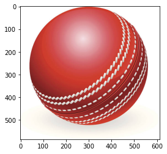

```
Cars = 10.103199875551644%
Ice cream cone = 8.37085128179928%
Cricket ball = 81.52594884264907%
The predicted image is : Cricket ball
```

```python
# change the model name accordingly to load and predict the image
model_name = 'ice_cricket_cars_svc'

model=pickle.load(open(f'{model_name}.p','rb'))
Categories=['Cars','Ice cream cone','Cricket ball']

# url=input('Enter URL of Image')
img=imread('/Users/srujanmara/Desktop/UTA Study/Summer 2022/Data Science/Project/test_images/cricball.jpg')
plt.imshow(img)
plt.show()
img_resize=resize(img,(150,150,3))
l=img_resize.flatten()  #img_resize.reshape(1,-1) #[img_resize.flatten()]
probability=model.predict_proba(l.reshape(1,-1))

for ind,val in enumerate(Categories):
    print(f'{val} = {probability[0][ind]*100}%')
print("The predicted image is : "+Categories[model.predict(l.reshape(1,-1))[0]])
```

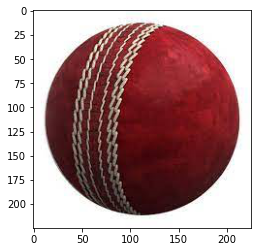

```
Cars = 11.560745312049203%
Ice cream cone = 2.2458589877762067%
Cricket ball = 86.19339570017462%
The predicted image is : Cricket ball
```

```python
# change the model name accordingly to load and predict the image
model_name = 'ice_cricket_cars_svc'

model=pickle.load(open(f'{model_name}.p','rb'))
Categories=['Cars','Ice cream cone','Cricket ball']

# url=input('Enter URL of Image')
img=imread('/Users/srujanmara/Desktop/UTA Study/Summer 2022/Data Science/Project/test_images/redball1.jpeg')
plt.imshow(img)
plt.show()
img_resize=resize(img,(150,150,3))
l=img_resize.flatten()  #img_resize.reshape(1,-1) #[img_resize.flatten()]
probability=model.predict_proba(l.reshape(1,-1))

for ind,val in enumerate(Categories):
    print(f'{val} = {probability[0][ind]*100}%')
print("The predicted image is : "+Categories[model.predict(l.reshape(1,-1))[0]])
```

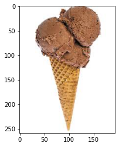

```
Cars = 2.651977878659085%
Ice cream cone = 90.83516736148113%
Cricket ball = 6.512854759859795%
The predicted image is : Ice cream cone
```

```python
# change the model name accordingly to load and predict the image
model_name = 'ice_cricket_cars_svc'

model=pickle.load(open(f'{model_name}.p','rb'))
Categories=['Cars','Ice cream cone','Cricket ball']

# url=input('Enter URL of Image')
img=imread('/Users/srujanmara/Desktop/UTA Study/Summer 2022/Data Science/Project/test_images/icecone1.jpg')
plt.imshow(img)
plt.show()
img_resize=resize(img,(150,150,3))
l=img_resize.flatten()  #img_resize.reshape(1,-1) #[img_resize.flatten()]
probability=model.predict_proba(l.reshape(1,-1))

for ind,val in enumerate(Categories):
    print(f'{val} = {probability[0][ind]*100}%')
print("The predicted image is : "+Categories[model.predict(l.reshape(1,-1))[0]])
```

[figure not shown]

```
Cars = 84.53265430447789%
Ice cream cone = 2.8169088007159955%
Cricket ball = 12.650436894806097%
The predicted image is : Cars
```

```python
# change the model name accordingly to load and predict the image
model_name = 'ice_cricket_cars_svc'

model=pickle.load(open(f'{model_name}.p','rb'))
Categories=['Cars','Ice cream cone','Cricket ball']

# url=input('Enter URL of Image')
img=imread('/Users/srujanmara/Desktop/UTA Study/Summer 2022/Data Science/Project/test_images/car2.jpeg')
plt.imshow(img)
plt.show()
img_resize=resize(img,(150,150,3))
l=img_resize.flatten()  #img_resize.reshape(1,-1) #[img_resize.flatten()]
probability=model.predict_proba(l.reshape(1,-1))

for ind,val in enumerate(Categories):
    print(f'{val} = {probability[0][ind]*100}%')
print("The predicted image is : "+Categories[model.predict(l.reshape(1,-1))[0]])
```

## The trained model is correctly classifiying the images which are not seen